# Proyección del Tipo de Cambio Digital en Bolivia

SARIMA, SARIMAX e Intervenciones

Análisis Econométrico

17 de julio de 2026

# 1 Datos y Descomposición Estacional

Serie: **log(TC digital)** desde **noviembre 2023** (32 observaciones mensuales) hasta **junio 2026**.

> **Nota de muestra:** con solo 32 meses (menos de 3 años), la identificación de un componente estacional $s=12$ es mucho más incierta que en los modelos de inflación (que usan series de 7+ años). Los resultados de este reporte —especialmente cualquier patrón estacional— deben tratarse como **exploratorios**.

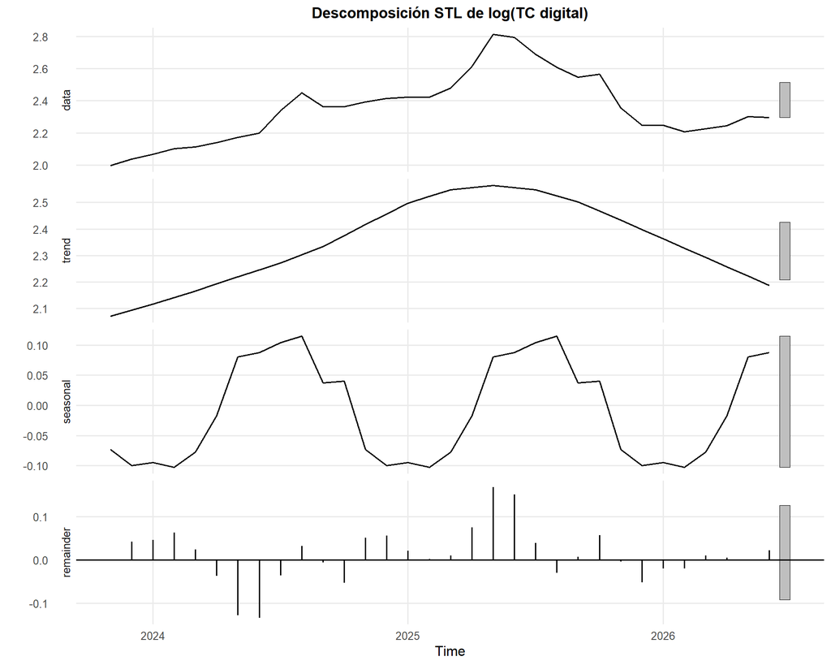

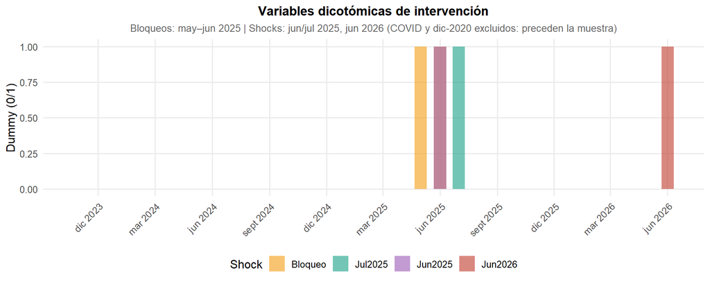

# 2 Pruebas de Raíz Unitaria y Estacionalidad

Pruebas de raíz unitaria

| Prueba | Serie | Estadístico | p-valor | Conclusión |
| --- | --- | --- | --- | --- |
| **log(TC digital)** |  |  |  |  |
| ADF | log(TC digital) | -1.5195 | 0.7582 | No estac. |
| PP | log(TC digital) | -3.5495 | 0.9054 | No estac. |
| KPSS | log(TC digital) | 0.1935 | 0.0184 | No estac. |
| Zivot-Andrews | log(TC digital) | -4.1681 | 0.1000 | No estac. |
| **Δlog(TC)** |  |  |  |  |
| ADF | Δlog(TC) | -2.4585 | 0.3962 | No estac. |
| PP | Δlog(TC) | -19.0781 | 0.0406 | Estac. |
| KPSS | Δlog(TC) | 0.2739 | 0.1000 | Estac. |
| Zivot-Andrews | Δlog(TC) | -3.2056 | 0.1000 | No estac. |

> Zivot-Andrews: quiebre en **oct 2025** (log(TC)) y **jun 2025** (Δlog(TC)). Diferenciación regular: **d = 1**. Diferenciación estacional: **D = 0**.

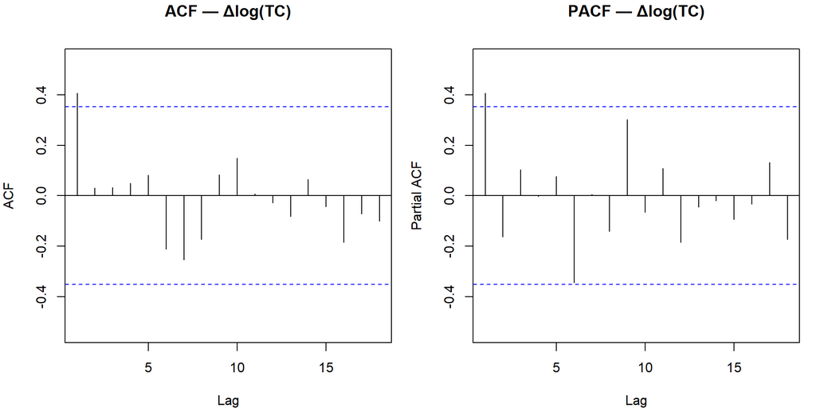

# 3 Modelo A: SARIMA Puro

Se estiman SARIMA$(p,d,q)(P,D,Q)_{12}$ sobre log(TC digital) con $d=1$, $D=0$, $p,q \in [0,2]$, $P,Q \in [0,1]$.

Modelo A: SARIMA puro — Top 15 de 35 modelos

| Modelo | AICc | BIC | HQ | RMSE | MAPE | LB(p) | Score |
| --- | --- | --- | --- | --- | --- | --- | --- |
| (0,1,1)(1,0,1)[12] | -70.09 | -65.89 | -69.76 | 0.05508 | 1.644 | 0.2418 | -3.188 |
| (1,1,1)(1,0,1)[12] | -68.72 | -63.95 | -68.79 | 0.05550 | 1.599 | 0.4775 | -2.624 |
| (0,1,2)(1,0,1)[12] | -68.42 | -63.65 | -68.48 | 0.05518 | 1.623 | 0.4284 | -2.441 |
| (1,1,1)(0,0,0)[12] | -72.80 | -69.38 | -72.28 | 0.06390 | 1.869 | 0.6085 | -1.795 |
| (1,1,2)(1,0,1)[12] | -65.88 | -60.77 | -66.57 | 0.05507 | 1.545 | 0.3869 | -1.775 |
| (0,1,1)(0,0,1)[12] | -72.17 | -68.76 | -71.66 | 0.06257 | 1.873 | 0.3355 | -1.770 |
| (2,1,1)(1,0,1)[12] | -65.90 | -60.80 | -66.60 | 0.05531 | 1.555 | 0.3521 | -1.695 |
| (1,1,1)(0,0,1)[12] | -70.88 | -66.68 | -70.55 | 0.06277 | 1.777 | 0.5698 | -1.493 |
| (2,1,1)(0,0,0)[12] | -70.77 | -66.58 | -70.44 | 0.06262 | 1.779 | 0.5715 | -1.468 |
| (1,1,2)(0,0,0)[12] | -70.57 | -66.37 | -70.24 | 0.06280 | 1.798 | 0.5737 | -1.264 |
| (0,1,1)(1,0,0)[12] | -71.64 | -68.22 | -71.12 | 0.06464 | 1.881 | 0.2350 | -1.194 |
| (0,1,2)(0,0,1)[12] | -70.59 | -66.39 | -70.26 | 0.06260 | 1.822 | 0.5129 | -1.175 |
| (1,1,1)(1,0,0)[12] | -70.66 | -66.47 | -70.33 | 0.06347 | 1.806 | 0.5639 | -1.145 |
| (0,1,2)(0,0,0)[12] | -71.95 | -68.53 | -71.43 | 0.06520 | 1.931 | 0.3690 | -0.945 |
| (0,1,1)(0,0,0)[12] | -72.64 | -70.20 | -72.14 | 0.06823 | 1.953 | 0.4343 | -0.915 |

> **Ganador A:** (0,1,1)(1,0,1)[12] (Score = -3.188)

# 4 Modelo B: SARIMA + Intervenciones

Se agregan dummies de **Bloqueos** (may–jun 2025) y shocks puntuales (jun/jul 2025, jun 2026) como regresores exógenos.

Modelo B: SARIMA + Intervenciones — Top 15 de 35 modelos

| Modelo | AICc | BIC | HQ | RMSE | MAPE | LB(p) | Score |
| --- | --- | --- | --- | --- | --- | --- | --- |
| (1,1,1)(1,0,1)[12] | -62.49 | -58.15 | -66.85 | 0.04748 | 1.323 | 0.2737 | -3.406 |
| (0,1,2)(1,0,1)[12] | -61.94 | -57.61 | -66.30 | 0.04719 | 1.376 | 0.2507 | -2.850 |
| (0,1,1)(1,0,1)[12] | -64.09 | -59.16 | -66.90 | 0.04917 | 1.469 | 0.2216 | -2.349 |
| (1,1,1)(0,0,0)[12] | -68.67 | -63.51 | -70.27 | 0.05548 | 1.533 | 0.3603 | -2.078 |
| (2,1,1)(1,0,1)[12] | -58.06 | -54.72 | -64.39 | 0.04752 | 1.319 | 0.1615 | -2.044 |
| (1,1,1)(0,0,1)[12] | -65.86 | -60.93 | -68.66 | 0.05369 | 1.500 | 0.3962 | -1.726 |
| (1,1,1)(1,0,0)[12] | -65.52 | -60.60 | -68.33 | 0.05486 | 1.495 | 0.3647 | -1.391 |
| (0,1,1)(0,0,0)[12] | -69.59 | -64.49 | -70.29 | 0.05996 | 1.574 | 0.4027 | -1.191 |
| (0,1,2)(0,0,0)[12] | -67.89 | -62.73 | -69.49 | 0.05589 | 1.602 | 0.2984 | -1.155 |
| (2,1,2)(1,0,1)[12] | -53.62 | -51.74 | -62.38 | 0.04728 | 1.280 | 0.0729 | -1.148 |
| (0,1,2)(0,0,1)[12] | -65.29 | -60.37 | -68.10 | 0.05313 | 1.570 | 0.3691 | -1.087 |
| (2,1,1)(0,0,0)[12] | -65.04 | -60.11 | -67.84 | 0.05551 | 1.522 | 0.2579 | -0.857 |
| (1,1,2)(0,0,0)[12] | -65.01 | -60.08 | -67.82 | 0.05550 | 1.530 | 0.2546 | -0.788 |
| (0,1,1)(0,0,1)[12] | -67.30 | -62.13 | -68.89 | 0.05586 | 1.648 | 0.2908 | -0.586 |
| (2,1,1)(0,0,1)[12] | -61.84 | -57.51 | -66.21 | 0.05375 | 1.494 | 0.2694 | -0.421 |

Efecto estimado de las intervenciones sobre log(TC digital)

| Intervención | Coeficiente | Err. Std. | z | p-valor |  |
| --- | --- | --- | --- | --- | --- |
| Bloqueo | 0.12456 | 0.04890 | 2.547 | 0.0109 | ** |
| Shock_Jun2025 | 0.02910 | 0.04930 | 0.590 | 0.5550 |  |
| Shock_Jul2025 | 0.02021 | 0.05324 | 0.380 | 0.7043 |  |
| Shock_Jun2026 | -0.01440 | 0.06211 | -0.232 | 0.8167 |  |

> **Ganador B:** (1,1,1)(1,0,1)[12] (Score = -3.406)

# 5 Modelo C: SARIMAX (con inflación interanual)

Se incorpora la **inflación interanual** como variable exógena, junto a las dummies de intervención — el espejo exacto del SARIMAX de inflación (que usaba el TC digital como exógena).

Modelo C: SARIMAX — Top 15 de 35 modelos

| Modelo | AICc | BIC | HQ | RMSE | MAPE | LB(p) | Score |
| --- | --- | --- | --- | --- | --- | --- | --- |
| (1,1,1)(1,0,1)[12] | -58.38 | -55.04 | -64.70 | 0.04814 | 1.323 | 0.1653 | -2.730 |
| (1,1,1)(0,0,0)[12] | -65.95 | -61.02 | -68.76 | 0.05468 | 1.498 | 0.3141 | -2.479 |
| (0,1,2)(1,0,1)[12] | -57.95 | -54.61 | -64.28 | 0.04780 | 1.373 | 0.1490 | -2.351 |
| (0,1,2)(0,0,0)[12] | -65.36 | -60.43 | -68.16 | 0.05492 | 1.563 | 0.2464 | -1.821 |
| (0,1,1)(1,0,1)[12] | -60.18 | -55.84 | -64.54 | 0.04970 | 1.485 | 0.1195 | -1.804 |
| (1,1,1)(0,0,1)[12] | -62.35 | -58.01 | -66.71 | 0.05399 | 1.468 | 0.2822 | -1.682 |
| (1,1,1)(1,0,0)[12] | -62.23 | -57.90 | -66.60 | 0.05434 | 1.468 | 0.2716 | -1.564 |
| (1,1,2)(1,0,1)[12] | -53.49 | -51.61 | -62.24 | 0.04813 | 1.326 | 0.0798 | -1.374 |
| (0,1,1)(0,0,0)[12] | -67.07 | -61.90 | -68.67 | 0.05927 | 1.575 | 0.4818 | -1.371 |
| (2,1,1)(1,0,1)[12] | -53.50 | -51.62 | -62.25 | 0.04811 | 1.330 | 0.0813 | -1.359 |
| (1,1,2)(0,0,0)[12] | -61.93 | -57.60 | -66.30 | 0.05466 | 1.501 | 0.2063 | -1.189 |
| (2,1,1)(0,0,0)[12] | -61.94 | -57.61 | -66.30 | 0.05462 | 1.506 | 0.2079 | -1.170 |
| (0,1,2)(0,0,1)[12] | -61.90 | -57.56 | -66.26 | 0.05391 | 1.541 | 0.2565 | -1.090 |
| (0,1,2)(1,0,0)[12] | -61.73 | -57.39 | -66.09 | 0.05446 | 1.536 | 0.2355 | -0.945 |
| (1,1,2)(0,0,1)[12] | -57.93 | -54.59 | -64.25 | 0.05396 | 1.471 | 0.1716 | -0.363 |

Coeficientes de regresores exógenos en SARIMAX

| Variable | Coeficiente | Err. Std. | z | p-valor |  |
| --- | --- | --- | --- | --- | --- |
| Bloqueo | 0.11302 | 0.05392 | 2.096 | 0.0361 | ** |
| Shock_Jun2025 | 0.01483 | 0.05559 | 0.267 | 0.7896 |  |
| Shock_Jul2025 | 0.00579 | 0.05922 | 0.098 | 0.9222 |  |
| Shock_Jun2026 | -0.00286 | 0.06521 | -0.044 | 0.9651 |  |
| Inf_ia | 0.00521 | 0.00935 | 0.557 | 0.5777 |  |

> **Ganador C:** (1,1,1)(1,0,1)[12] (Score = -2.73)

> La inflación interanual NO es significativa al 5%, por lo que **C se reporta como modelo exploratorio / escenario condicionado a la inflación**, no como candidato a modelo base — el criterio decisivo es el desempeño fuera de muestra (sección Backtesting).

# 6 Comparación de los Tres Enfoques

Comparación de los tres enfoques

| Criterio | A: SARIMA | B: + Intervenciones | C: + Inflación exógena |
| --- | --- | --- | --- |
| Modelo | (0,1,1)(1,0,1)[12] | (1,1,1)(1,0,1)[12] | (1,1,1)(1,0,1)[12] |
| Score | -3.188 | -3.406 | -2.73 |
| AICc | -70.09 | -62.49 | -58.38 |
| BIC | -65.89 | -58.15 | -55.04 |
| HQ | -69.76 | -66.85 | -64.7 |
| RMSE | 0.05508 | 0.04748 | 0.04814 |
| MAPE | 1.644 | 1.323 | 1.323 |
| Ljung-Box (p) | 0.2418 | 0.2737 | 0.1653 |

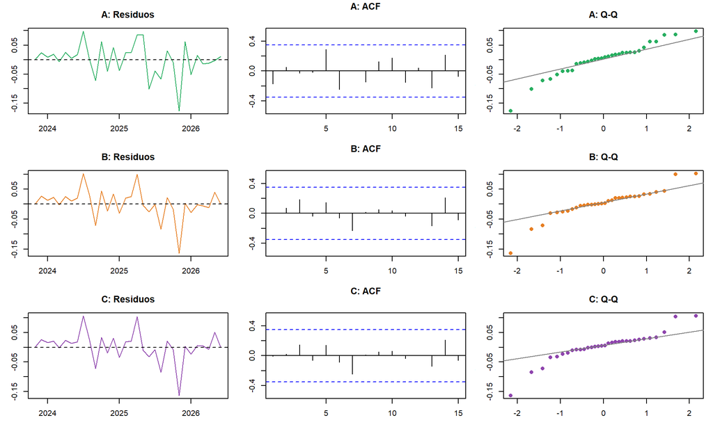

# 7 Backtesting

Backtesting — TC digital pronosticado por modelo

| Fecha | TC obs. | A: SARIMA | B: +Interv. | C: +Inflación |
| --- | --- | --- | --- | --- |
| ene 2026 | 9.4736 | 10.1670 | NA | NA |
| feb 2026 | 9.0775 | 10.0867 | NA | NA |
| mar 2026 | 9.2585 | 10.2712 | NA | NA |
| abr 2026 | 9.4446 | 10.7076 | NA | NA |
| may 2026 | 10.0009 | 11.4113 | NA | NA |
| jun 2026 | 9.9393 | 11.2671 | NA | NA |

Métricas de backtesting comparadas

| Métrica | A: SARIMA | B: +Interv. | C: +Inflación |
| --- | --- | --- | --- |
| RMSE (TC) | 1.1455 | NaN | NaN |
| MAPE (%) | 11.7% | NaN% | NaN% |

## 7.1 Backtesting - Top 10 candidatos por categoria

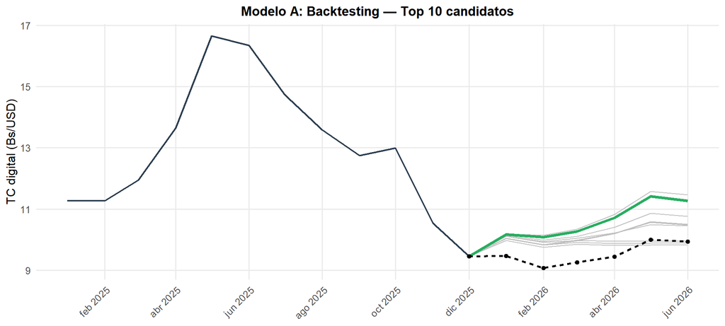

[figure not shown]

[figure not shown]

## 7.2 Backtesting — Comparación de ganadores

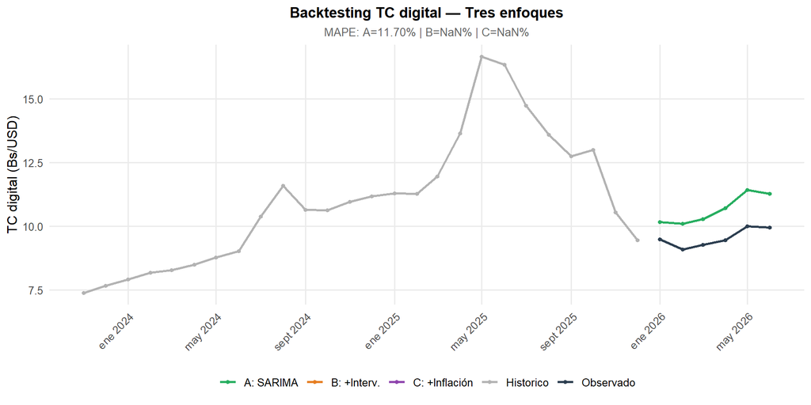

# 8 Pronóstico

## 8.1 Proyección comparada — TC digital

Proyección de TC digital (Bs/USD) — Tres enfoques

| Mes | A: SARIMA | B: +Interv. | C: +Inflación |
| --- | --- | --- | --- |
| Julio | 9.2999 | 9.7761 | 9.6139 |
| Agosto | 8.7582 | 9.3690 | 9.2642 |
| Septiembre | 8.7160 | 9.3315 | 9.2570 |
| Octubre | 8.7876 | 9.3934 | 9.3431 |
| Noviembre | 8.0187 | 8.6915 | 8.7802 |
| Diciembre | 7.6400 | 8.3425 | 8.4982 |
| Enero | 7.6692 | 8.3726 | 8.5618 |

## 8.2 TC digital — Tres enfoques

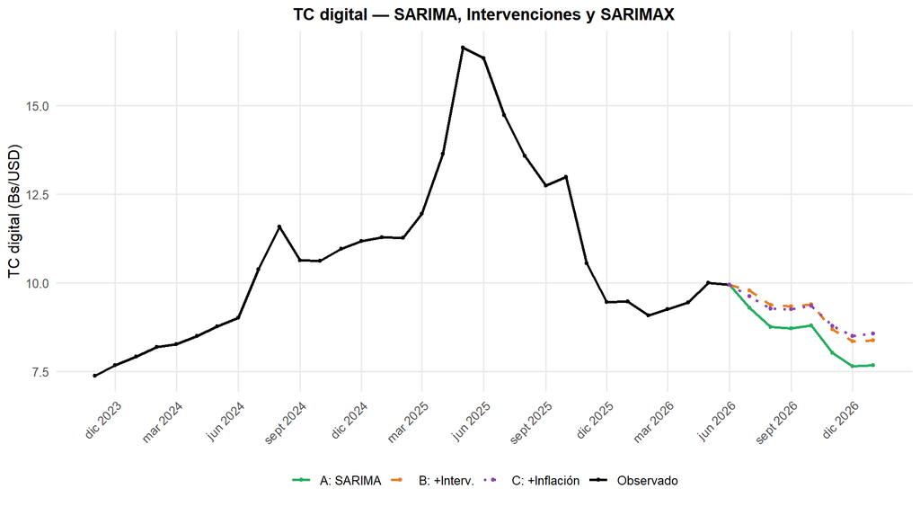

## 8.3 Fan chart — Modelo recomendado (A (SARIMA puro))

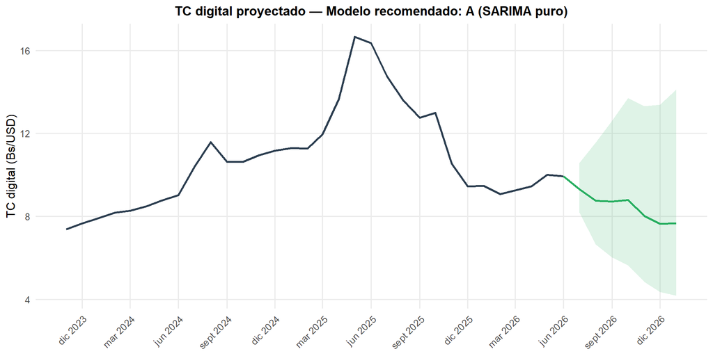

*Modelos estimados sobre log(TC digital) desde nov 2023 (n=32).* *A: SARIMA puro | B: + dummies Bloqueos y shocks puntuales | C: + inflación interanual.* *Muestra corta (< 3 años): tratar cualquier señal estacional como exploratoria.*